# CPU Performance Statistics Final

Deniz Bilgin

2024-06-05

## 1. Data:

**Please find your original dataset or datasets; and describe your data in the first step.**

I found the data set called **CPU Performance** from the **WOLFRAM DATA REPOSITORY** site. The content of the data, as the name suggests, is related to the performance of different CPUs and is in **CSV** format. The data contains a total of **209 rows** and **10 columns**. Link of the dataset is: https://datarepository.wolframcloud.com/resources/Sample-Data-CPU-Performance/

Head (first 6 row) of the raw data is like that:

```r
data = read.csv("./Sample-Data-CPU-Performance.csv")
head(data)
```

```
##   Manufacturer   Model                    CycleTime           MinimumMainMemory
## 1      ADVISOR   32/60 Quantity[125, "Nanoseconds"]  Quantity[256, "Kilobytes"]
## 2       AMDAHL  470V/7  Quantity[29, "Nanoseconds"] Quantity[8000, "Kilobytes"]
## 3       AMDAHL  470/7A  Quantity[29, "Nanoseconds"] Quantity[8000, "Kilobytes"]
## 4       AMDAHL 470V/7B  Quantity[29, "Nanoseconds"] Quantity[8000, "Kilobytes"]
## 5       AMDAHL 470V/7C  Quantity[29, "Nanoseconds"] Quantity[8000, "Kilobytes"]
## 6       AMDAHL  470V/8  Quantity[26, "Nanoseconds"] Quantity[8000, "Kilobytes"]
##              MaximumMainMemory                  CacheSize
## 1  Quantity[6000, "Kilobytes"] Quantity[256, "Kilobytes"]
## 2 Quantity[32000, "Kilobytes"]  Quantity[32, "Kilobytes"]
## 3 Quantity[32000, "Kilobytes"]  Quantity[32, "Kilobytes"]
## 4 Quantity[32000, "Kilobytes"]  Quantity[32, "Kilobytes"]
## 5 Quantity[16000, "Kilobytes"]  Quantity[32, "Kilobytes"]
## 6 Quantity[32000, "Kilobytes"]  Quantity[64, "Kilobytes"]
##   MinimumNumberOfChannels MaximumNumberOfChannels PublishedPerformance
## 1                      16                     128                  198
## 2                       8                      32                  269
## 3                       8                      32                  220
## 4                       8                      32                  172
## 5                       8                      16                  132
## 6                       8                      32                  318
##   EstimatedPerformance
## 1                  199
## 2                  253
## 3                  253
## 4                  253
## 5                  132
## 6                  290
```

## 2. Exploratory and descriptive data analysis:

**Use “Exploratory and descriptive data analysis”. Talk about your categorical and quantitative data or your ordinal variables etc.**

The data is **raw** right now, I need to process the data a little and make it ready for statistical processes and tests.

I have coded a **preprocesser function** for numerical columns.

```r
preprocess_numeric_column <- function(data, column_name, unit_short_name) {
  data[[column_name]] <- as.numeric(gsub("Quantity\\[(\\d+), .*\\]", "\\1", data[[column_name]]))
  names(data)[names(data) == column_name] <- paste(column_name, " (", unit_short_name, ")", sep ="")
  return(data)
}
```

Now, I can use the preprocesser function.

```r
data <- preprocess_numeric_column(data, "CycleTime", "ns")
data <- preprocess_numeric_column(data, "MinimumMainMemory", "kB")
data <- preprocess_numeric_column(data, "MaximumMainMemory", "kB")
data <- preprocess_numeric_column(data, "CacheSize", "kB")

head(data)
```

```
##   Manufacturer   Model CycleTime (ns) MinimumMainMemory (kB)
## 1      ADVISOR   32/60            125                    256
## 2       AMDAHL  470V/7             29                   8000
## 3       AMDAHL  470/7A             29                   8000
## 4       AMDAHL 470V/7B             29                   8000
## 5       AMDAHL 470V/7C             29                   8000
## 6       AMDAHL  470V/8             26                   8000
##   MaximumMainMemory (kB) CacheSize (kB) MinimumNumberOfChannels
## 1                   6000            256                      16
## 2                  32000             32                       8
## 3                  32000             32                       8
## 4                  32000             32                       8
## 5                  16000             32                       8
## 6                  32000             64                       8
##   MaximumNumberOfChannels PublishedPerformance EstimatedPerformance
## 1                     128                  198                  199
## 2                      32                  269                  253
## 3                      32                  220                  253
## 4                      32                  172                  253
## 5                      16                  132                  132
## 6                      32                  318                  290
```

Before the seeing the summary, I have to see the **value counts** of the Manufacturer column:

```r
manufacturer_counts <- table(data$Manufacturer)
manufacturer_counts
```

```
##
##      ADVISOR       AMDAHL     APOLLODN         BASF          BTI    BURROUGHS
##            1            9            2            2            2            8
##       C.R.D.       CAMBEX     CDCCYBER     CDCOMEGA          DEC         DECD
##            6            5            6            3            4            2
##           DG    FORMATION    FOURPHASE GOULDCONCEPT       HARRIS    HONEYWELL
##            7            5            1            3            7           13
##           HP          IBM          IPL     MAGNUSON    MICRODATA          NAS
##            7           32            6            6            1           19
##          NCR      NIXDORF  PERKINELMER        PRIME      SIEMENS       SPERRY
##           13            3            3            5           12           13
##      STRATUS         WANG
##            1            2
```

Let’s look at the **summary** of the data to recognize what type the columns are. The summary of the data tells us most of the required things for this question.

```
##  Manufacturer          Model           CycleTime (ns)   MinimumMainMemory (kB)
##  Length:209         Length:209         Min.   :  17.0   Min.   :   64
##  Class :character   Class :character   1st Qu.:  50.0   1st Qu.:  768
##  Mode  :character   Mode  :character   Median : 110.0   Median : 2000
##                                        Mean   : 203.8   Mean   : 2868
##                                        3rd Qu.: 225.0   3rd Qu.: 4000
##                                        Max.   :1500.0   Max.   :32000
##  MaximumMainMemory (kB) CacheSize (kB)   MinimumNumberOfChannels
##  Min.   :   64          Min.   :  0.00   Min.   : 0.000
##  1st Qu.: 4000          1st Qu.:  0.00   1st Qu.: 1.000
##  Median : 8000          Median :  8.00   Median : 2.000
##  Mean   :11796          Mean   : 25.21   Mean   : 4.699
##  3rd Qu.:16000          3rd Qu.: 32.00   3rd Qu.: 6.000
##  Max.   :64000          Max.   :256.00   Max.   :52.000
##  MaximumNumberOfChannels PublishedPerformance EstimatedPerformance
##  Min.   :  0.00          Min.   :   6.0       Min.   :  15.00
##  1st Qu.:  5.00          1st Qu.:  27.0       1st Qu.:  28.00
##  Median :  8.00          Median :  50.0       Median :  45.00
##  Mean   : 18.27          Mean   : 105.6       Mean   :  99.33
##  3rd Qu.: 24.00          3rd Qu.: 113.0       3rd Qu.: 101.00
##  Max.   :176.00          Max.   :1150.0       Max.   :1238.00
```

As you can see there are **1 categorical** columns, **8 numeric** columns, **1 string** columns and there are no boolean columns. When I examine the summary of the data after data preprocessing, I can access a lot of information about the data (Column types, mean values, quartiles and so on). With this part, I made the data set ready for statistical tests and observations, that is, I went through a **data preprocessing** stage.

## 3. Data Visualization:

**Use 2 useful, meaningful and different “data visualization techniques” which will help you understand your data further (distribution, outliers, variability, etc). And use another 2 visualizations to compare two groups (like female/male; smoker/nonsmoker etc).**

First of all, let’s examine a numeric column that called Published Performance.

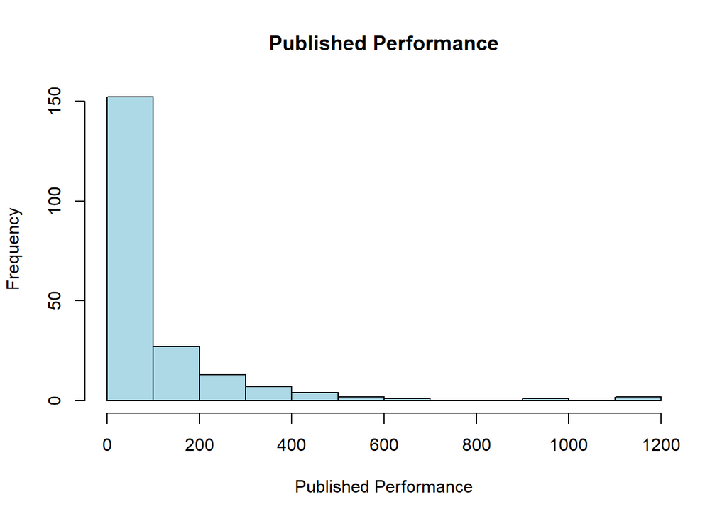

Since there are many numeric type columns in the data, let’s examine this column with a pie chart, which is the categorical Manufacturer column, instead of visualizing other numeric types again.

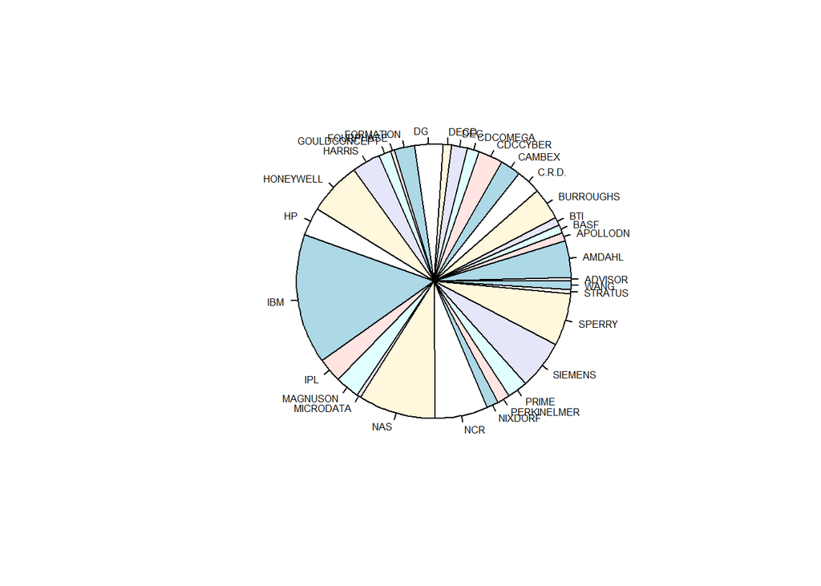

There are **32** different Manufacturers. The most common manufacturer is IBM, and second one is NAS.

Now, I can continue with the second part of the question. Firstly, I’ll compare Maximum Number of Channels of IBM and NAS. I’ll separate the column as 3 segments. Segments are **x<9**, **9<x<19** and **19<x**.

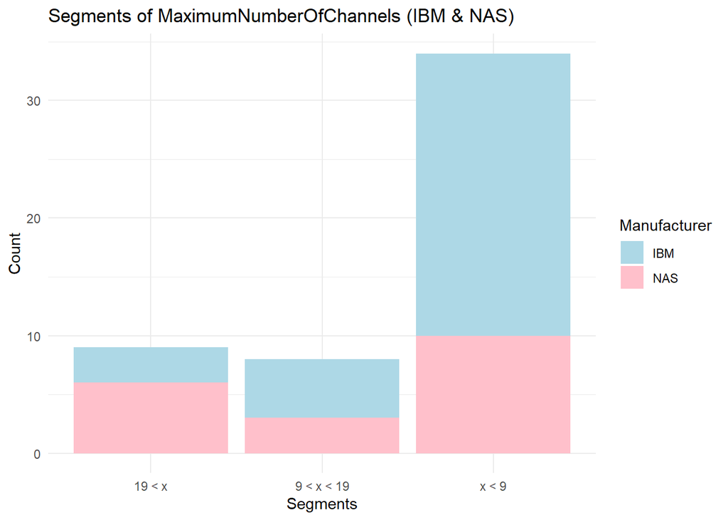

```r
data_ibm <- subset(data, Manufacturer == "IBM")
data_nas <- subset(data, Manufacturer == "NAS")

count_ibm_segment1 <- length(data_ibm$MaximumNumberOfChannels[data_ibm$MaximumNumberOfChannels < 9])
count_ibm_segment2 <- length(data_ibm$MaximumNumberOfChannels[data_ibm$MaximumNumberOfChannels >= 9 & data_ibm$MaximumNumberOfChannels < 19])
count_ibm_segment3 <- length(data_ibm$MaximumNumberOfChannels[data_ibm$MaximumNumberOfChannels >= 19])

count_nas_segment1 <- length(data_nas$MaximumNumberOfChannels[data_nas$MaximumNumberOfChannels < 9])
count_nas_segment2 <- length(data_nas$MaximumNumberOfChannels[data_nas$MaximumNumberOfChannels >= 9 & data_nas$MaximumNumberOfChannels < 19])
count_nas_segment3 <- length(data_nas$MaximumNumberOfChannels[data_nas$MaximumNumberOfChannels >= 19])

segments <- data.frame(
  Manufacturer = rep(c("IBM", "NAS"), each = 3),
  Segment = rep(c("x < 9", "9 < x < 19", "19 < x"), 2),
  Count = c(count_ibm_segment1, count_ibm_segment2, count_ibm_segment3, count_nas_segment1, count_nas_segment2, count_nas_segment3)
)

library(ggplot2)
ggplot(segments, aes(x = Segment, y = Count, fill = Manufacturer)) +
  geom_bar(stat = "identity") +
  scale_fill_manual(values = c("lightblue", "pink")) +
  labs(title = "Segments of MaximumNumberOfChannels (IBM & NAS)", x = "Segments", y = "Count") +
  theme_minimal()
```

When I examine this graph, I can see that IBM devices have more channels when the maximum number of channels is 19, and when we reach values greater than 19, NAS has more channels.

Now, I thought that I can compare IBM and NAS manufacturers by their estimated performance. I’ll use box plot to see and compare 5 number summary of them.

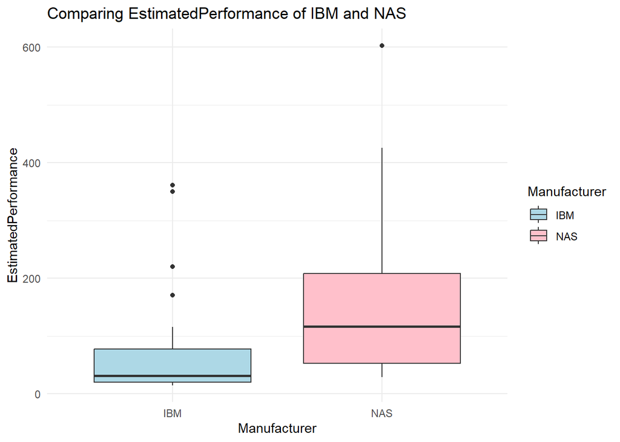

```r
combined_ibm_nas_data <- rbind(data_ibm, data_nas)
combined_ibm_nas_data$Manufacturer <- factor(combined_ibm_nas_data$Manufacturer)

ggplot(combined_ibm_nas_data, aes(x = Manufacturer, y = EstimatedPerformance, fill = Manufacturer)) +
  geom_boxplot() +
  scale_fill_manual(values = c("lightblue", "pink")) +
  labs(title = "Comparing EstimatedPerformance of IBM and NAS", x = "Manufacturer", y = "EstimatedPerformance") +
  theme_minimal()
```

I visualized the data in the EstimatedPerformance columns of the two companies that produce the most CPUs using a box plot. From this visualization it is clear that the expectation for the **average IBM device is much lower than for the average NAS device**. While IBM has plenty of outliers, NAS doesn’t seem to have that many. Both distributions show a **skewed** feature, but IBM’s distribution has a higher skew.

## 4. Confidence Intervals:

**Build ‘2 Confidence Intervals’ step by step.**

Firstly, I’ll calculate the confidence interval for CycleTime. Now, I’ll calculate the mean of the CycleTime column. The mean will help me to find confidence interval’s upper and lower points.

```r
mean_cycle_time <- mean(data$CycleTime)
mean_cycle_time
```

```
## [1] 203.823
```

Then, I have to calculate standard deviation and length of the CycleTime column.These calculations will help me to find standard error of the column. The formula of calculating standard error is **$\sigma$/sqrt(n)**.

```r
sd_cycle_time <- sd(data$CycleTime)
n <- length(data$CycleTime)
standard_error_cycle_time <- sd_cycle_time / sqrt(n)
standard_error_cycle_time
```

```
## [1] 18.00276
```

I’ll choose **95%** for the confidence interval, so the **z-value is 1.96**. Now, I will calculate upper and lower limits of %95 confidence interval by using z-value and standard error.

```r
z_value_95 <- 1.96
conf_int_lower_cycle_time <- mean_cycle_time - (z_value_95 * standard_error_cycle_time)
conf_int_upper_cycle_time <- mean_cycle_time + (z_value_95 * standard_error_cycle_time)
conf_int_cycle_time <- c(conf_int_lower_cycle_time, conf_int_upper_cycle_time)
conf_int_cycle_time
```

```
## [1] 168.5376 239.1084
```

If the 95% confidence interval is [168.5376 239.1084] ns, this indicates that there is a **95% probability** that the true CycleTime mean is in this range.

In this time I’ll calculate the confidence intervar for CacheSize column. The steps are same as previous. I’ll calculate mean of the column to find the last equation.

```r
mean_cache_size <- mean(data$CacheSize)
mean_cache_size
```

```
## [1] 25.20574
```

Then, I’ll calculate standard deviation and length of the CacheSize column again. Variable n will be same, so I do not need to calculate it.

```r
sd_cache_size <- sd(data$CacheSize)
standard_error_cache_size <- sd_cache_size / sqrt(n)
standard_error_cache_size
```

```
## [1] 2.810347
```

Now, I have chosen the **99%** confidence interval and z-value will be **2.58**. Let’s calculate upper and lower limits again.

```r
z_value_99 <- 2.58
conf_int_lower_cache_size <- mean_cache_size - (z_value_99 * standard_error_cache_size)
conf_int_upper_cache_size <- mean_cache_size + (z_value_99 * standard_error_cache_size)
conf_int_cache_size <- c(conf_int_lower_cache_size, conf_int_upper_cache_size)
conf_int_cache_size
```

```
## [1] 17.95505 32.45644
```

If the 99% confidence interval is [17.95505 32.45644] kB, this indicates that there is a **99% probability** that the true CacheSize mean is in this range.

## 5. Transformation:

**Implement one transformation (log transformation, Box-Cok transformation, etc) for one of your quantitative variables, which is not normally distributed; but will be normal or more normal, after the transformation.**

In the 3rd part of the paper, there is a PublishedPerformance column’s histogram. As you can see there this graph is highly skewed. So, I can take **log** of the Published Performance column to reach **normal distribution**.

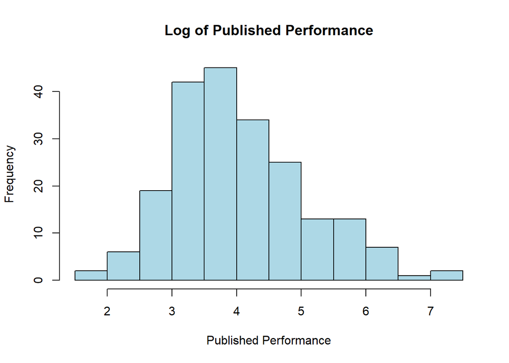

```r
published_performance_log <- log(data$PublishedPerformance + 1)
hist(published_performance_log, col="lightblue", main="Log of Published Performance", xlab="Published Performance")
```

With log using the Published Performance column look like a bit **skewed normal distribution** after transformation. By bringing the data to this state (bringing it closer to normal distribution), we can both facilitate the application of statistical tests and get more balanced results.

## 6. T-test (Welch t-test or Wilcoxon rank-sum test or Paired t-test)

**Implement a single t-test for one of your “normally or not-normally distributed” variable:**  
**a. Aim**  
In words, what is your objective here?  
**b. Hypothesis and level of significance:**  
Write your hypothesis in scientific form and determine the level of significance.  
**c. Which test you choose**  
Is your data independent or dependent?  
Tell why you chose this test.  
**d. Assumption Check :**  
Check the required assumptions statistically.  
**e. Result:**  
Give the output of the test and then write down the result.  
**f. Conclusion:**  
You got your result in item e. Write down the conclusion of your result, in such a way that, the reader who doesn’t know any statistics can understand your findings.  
**g. What can be Type-1 and Type-2 error here? Not definition! Tell these situations in terms of your data.**

```r
shapiro.test(data$MaximumMainMemory)
```

```
##
##  Shapiro-Wilk normality test
##
## data:  data$MaximumMainMemory
## W = 0.75761, p-value < 2.2e-16
```

```r
wilcox_test <- wilcox.test(data$MaximumMainMemory, mu=12000)
wilcox_test
```

```
##
##  Wilcoxon signed rank test with continuity correction
##
## data:  data$MaximumMainMemory
## V = 7419.5, p-value = 0.00171
## alternative hypothesis: true location is not equal to 12000
```

## 7. ANOVA and Tukey Test

**a. Aim**  
In words, what is your objective here?  
**b. Hypothesis and level of significance:**  
Choose more than 2 (≥3) groups to compare! Write your hypothesis in scientific form and determine the level of significance.  
**c. Assumption Check:**  
Check the required assumptions statistically.  
**d. Result of ANOVA:**  
Give the output of the test and then write down the result.  
**e. Conclusion of ANOVA:** You got your result in item d. Write down the conclusion of your result, in such a way that, the reader who doesn’t know any statistics can understand your findings.  
**f. Result of Tukey:**  
Give the output of the test and write down the result.  
**g. Conclusion of Tukey:**  
You got your result in item f. Write down the conclusion of your result, in such a way that, the reader who doesn’t know any statistics can understand your findings.

**a)**  
My aim is to **compare** the published performances of different CPU manufacturers using ANOVA and Tukey Test.  
**b)**  
I’ll compare some manufacturers’ published performances. These manufacturers are **SIEMENS**, **HONEYWELL** and **NCR**.  
H0 (The Null Hypothesis): $\mu$_siemens = $\mu$_honeywell = $\mu$_ncr  
H1 (The Alternative Hypothesis): $\mu$_siemens ≠ $\mu$_honeywell ≠ $\mu$_ncr  
**c)**  
When checking the assumptions, I must check that the data has a **normal distribution**, is there **homogeneous variance**, and the **observations are independent**. I will conduct appropriate tests for each of these assumptions and interpret the results I obtain. These manufacturers are independent.

```r
data_siemens <- subset(data, Manufacturer == "SIEMENS")
data_honeywell <- subset(data, Manufacturer == "HONEYWELL")
data_ncr <- subset(data, Manufacturer == "NCR")

shapiro_test_siemens <- shapiro.test(data_siemens$PublishedPerformance)
shapiro_test_honeywell <- shapiro.test(data_honeywell$PublishedPerformance)
shapiro_test_ncr <- shapiro.test(data_ncr$PublishedPerformance)
shapiro_test_results <- c(shapiro_test_siemens$p.value, shapiro_test_honeywell$p.value, shapiro_test_ncr$p.value)

if (all(shapiro_test_results > 0.05)) {
  "All of the populations have normal distribution"
} else {
  "All of the populations have not normal distribution"
}
```

```
## [1] "All of the populations have not normal distribution"
```

This output means that some of population members **have not normal distribution**.  
Now I’ll apply Levene Test to see variances of populations.

```r
library(car)
levene_test_results <- leveneTest(PublishedPerformance ~ Manufacturer, data = rbind(data_siemens, data_honeywell, data_ncr))
levene_test_results
```

```
## Levene's Test for Homogeneity of Variance (center = median)
##       Df F value  Pr(>F)
## group  2  2.7222 0.07965 .
##       35
## ---
## Signif. codes:  0 '***' 0.001 '**' 0.01 '*' 0.05 '.' 0.1 ' ' 1
```

As you can see p-value is equal to **0.079**, so it is greater than alpha (0.05). As a result, it can be said that the **variances are homogeneous**.  
**d)**  
I’ll apply ANOVA Test now.  
I’ve chosen the alpha (level of significance) as 0.05.

```r
anova_result <- aov(PublishedPerformance ~ Manufacturer, data = rbind(data_siemens, data_honeywell, data_ncr))
summary(anova_result)
```

```
##              Df Sum Sq Mean Sq F value Pr(>F)
## Manufacturer  2  29560   14780   2.187  0.127
## Residuals    35 236544    6758
```

P-value of ANOVA test is **0.127**, so that is greater than alpha (0.05). **H0** (The Null Hypothesis) **can not be rejected**. There is **no statistically significant difference** in PublishedPerformance values between the populations.  
**e)**  
I applied statistical tests to see and prove how similar mean of the published performance values of three different CPU manufacturers (Siemens, Honeywell and NCR) are. The result of the tests is that there is no significant difference between the published performance values of the manufacturers. That is, the performances of these three manufacturers are statistically similar to each other.  
**f)**  
Now, let’s apply Tukey Test.

```r
tukey_result <- TukeyHSD(anova_result)
tukey_result
```

```
##   Tukey multiple comparisons of means
##     95% family-wise confidence level
##
## Fit: aov(formula = PublishedPerformance ~ Manufacturer, data = rbind(data_siemens, data_honeywell, data_ncr))
##
## $Manufacturer
##                        diff       lwr       upr     p adj
## NCR-HONEYWELL      2.846154 -76.06671  81.75902 0.9957145
## SIEMENS-HONEYWELL 61.371795 -19.16831 141.91190 0.1640174
## SIEMENS-NCR       58.525641 -22.01447 139.06575 0.1916057
```

When I examined the Tukey Test results, I observed that all the p-values was greater than alpha (0.05) for **all pairs**. That means, **H0** (The Null Hypothesis) **can not be rejected**.  
**g)**  
I could **not see a significant difference** in the mean of performance values of the 3 manufacturers whose published performances I compared in statistical tests. The results of the previous ANOVA test I applied and the Tukey **tests match**.

## 8. Multiple Linear Regression

**a. Aim**  
In words, what is your objective here?.  
**b. Variable Selection:**  
Multiple linear regression (MLR) is a statistical technique that uses several explanatory variables to predict the outcome of a response variable. Which ones are your explanatory variables and which one is your response variable?  
**c. Regression Equation:**  
Write down the “statistical/mathematical equation” of your regression function using those variables and the parameters.  
**d. Hypothesis and level of significance**  
Write your hypothesis in scientific form and determine the level of significance.  
**e. Find the Best Model:**  
Use step function and find the best model, describe the reason which makes it the best one.  
**f. Assumption Check:**  
Check the required assumptions statistically.  
**g. Result**  
Give the output of the best model and write down the result.  
**h. Conclusion:**  
You got your result in item f. Write down the conclusion of your result, in such a way that, the reader who doesn’t know any statistics can understand your findings.

**a)**
My aim is to predict the cycle time of different CPUs. I will try to improve the prediction accuracy by using various system features for this prediction. As the algorithm, I will use multiple linear regression as in the title of this section.
**b)**
My dependent variable (target to predict) will be CycleTime (ns). I will use the variables MinimumMainMemory (kB), MaximumMainMemory (kB), CacheSize (kB), MinimumNumberOfChannels, MaximumNumberOfChannels, PublishedPerformance as features. The reason why I do not use the EstimatedPerformance column is that the values of both are already very close and to prevent the algorithm from learning a bias from this and reducing the model accuracy.
**c)**
The multiple linear regression formula for this part will be like that:
$$CycleTime=β_0 + β_1×MinimumMainMemory + β_2×MaximumMainMemory +
β_3×CacheSize + β_4×MinimumNumberOfChannels +
β_5×MaximumNumberOfChannels + β_6×PublishedPerformance +
\sum_{i=1}^{k-1} \gamma_i × \text{Manufacturer}_i$$
I have to process my categorical column that named Manufacturer before the creating the model.

```r
data$Manufacturer <- as.factor(data$Manufacturer)
mlr_model <- lm(data$CycleTime ~ data$MinimumMainMemory + data$MaximumMainMemory + data$CacheSize + data$MinimumNumberOfChannels + data$MaximumNumberOfChannels + data$PublishedPerformance + data$Manufacturer)
```

**d)**  
I have two hypothesis H0 and H1.  
H0 (The Null Hypothesis): $\beta_0 = \beta_1 = \beta_2 = \beta_3 = \beta_4 = \beta_5 = \beta_6 = ManufacturerCoefs (\gamma_1, ... \gamma_{k-1}) = 0$  
H1 (The Alternative Hypothesis): At least one $β$ coefficient is **different from zero**, meaning that at least one independent variable has a significant effect on the dependent variable.  
Also, I determined the alpha (level of significance) as **0.05** (5%).  
**e)**  
I will use the **step function** to find the best model as stated in the question.

```r
best_mlr_model <- step(mlr_model)
```

```
## Start:  AIC=2233.52
## data$CycleTime ~ data$MinimumMainMemory + data$MaximumMainMemory +
##     data$CacheSize + data$MinimumNumberOfChannels + data$MaximumNumberOfChannels +
##     data$PublishedPerformance + data$Manufacturer
##
##                                Df Sum of Sq      RSS    AIC
## - data$CacheSize                1      1008  6360180 2231.6
## - data$MaximumNumberOfChannels  1     12672  6371844 2231.9
## - data$MinimumNumberOfChannels  1     15941  6375113 2232.1
## - data$MinimumMainMemory        1     58376  6417548 2233.4
## - data$PublishedPerformance     1     58850  6418022 2233.4
## <none>                                       6359172 2233.5
## - data$MaximumMainMemory        1    469057  6828230 2246.4
## - data$Manufacturer            31   4931047 11290219 2291.5
##
## Step:  AIC=2231.56
## data$CycleTime ~ data$MinimumMainMemory + data$MaximumMainMemory +
##     data$MinimumNumberOfChannels + data$MaximumNumberOfChannels +
##     data$PublishedPerformance + data$Manufacturer
##
##                                Df Sum of Sq      RSS    AIC
## - data$MaximumNumberOfChannels  1     12324  6372504 2230.0
## - data$MinimumNumberOfChannels  1     15043  6375223 2230.1
## - data$MinimumMainMemory        1     57664  6417844 2231.4
## <none>                                       6360180 2231.6
## - data$PublishedPerformance     1     70216  6430395 2231.8
## - data$MaximumMainMemory        1    471967  6832146 2244.5
## - data$Manufacturer            31   5186699 11546879 2294.2
##
## Step:  AIC=2229.96
## data$CycleTime ~ data$MinimumMainMemory + data$MaximumMainMemory +
##     data$MinimumNumberOfChannels + data$PublishedPerformance +
##     data$Manufacturer
##
##                                Df Sum of Sq      RSS    AIC
## - data$MinimumNumberOfChannels  1      8702  6381206 2228.2
## <none>                                       6372504 2230.0
## - data$MinimumMainMemory        1    112014  6484517 2231.6
## - data$PublishedPerformance     1    150980  6523483 2232.8
## - data$MaximumMainMemory        1    464948  6837451 2242.7
## - data$Manufacturer            31   5331048 11703552 2295.0
##
## Step:  AIC=2228.25
## data$CycleTime ~ data$MinimumMainMemory + data$MaximumMainMemory +
##     data$PublishedPerformance + data$Manufacturer
##
##                             Df Sum of Sq      RSS    AIC
## <none>                                    6381206 2228.2
## - data$MinimumMainMemory     1    123995  6505201 2230.3
## - data$PublishedPerformance  1    144120  6525326 2230.9
## - data$MaximumMainMemory     1    480164  6861369 2241.4
## - data$Manufacturer         31   5524540 11905745 2296.6
```

```r
summary(best_mlr_model)
```

```
##
## Call:
## lm(formula = data$CycleTime ~ data$MinimumMainMemory + data$MaximumMainMemory +
##     data$PublishedPerformance + data$Manufacturer)
##
## Residuals:
##     Min      1Q  Median      3Q     Max
## -402.88  -49.98   -6.92   36.82  981.28
##
## Coefficients:
##                                 Estimate Std. Error t value Pr(>|t|)
## (Intercept)                   102.504477 194.258395   0.528 0.598400
## data$MinimumMainMemory         -0.014220   0.007734  -1.839 0.067655 .
## data$MaximumMainMemory         -0.009321   0.002576  -3.618 0.000388 ***
## data$PublishedPerformance       0.414447   0.209066   1.982 0.049012 *
## data$ManufacturerAMDAHL       288.526991 219.054515   1.317 0.189521
## data$ManufacturerAPOLLODN     322.375129 236.708805   1.362 0.174988
## data$ManufacturerBASF          59.344218 238.005128   0.249 0.803392
## data$ManufacturerBTI          242.130174 237.977101   1.017 0.310351
## data$ManufacturerBURROUGHS     90.231201 206.916657   0.436 0.663323
## data$ManufacturerC.R.D.       246.306346 209.085538   1.178 0.240398
## data$ManufacturerCAMBEX        64.358748 215.299533   0.299 0.765353
## data$ManufacturerCDCCYBER      19.217825 208.771663   0.092 0.926763
## data$ManufacturerCDCOMEGA      -8.995098 223.973119  -0.040 0.968010
## data$ManufacturerDEC          477.132578 216.919286   2.200 0.029154 *
## data$ManufacturerDECD         108.083199 237.338104   0.455 0.649391
## data$ManufacturerDG           275.171365 207.897385   1.324 0.187375
## data$ManufacturerFORMATION    768.739204 213.807100   3.595 0.000422 ***
## data$ManufacturerFOURPHASE     24.177021 272.392969   0.089 0.929376
## data$ManufacturerGOULDCONCEPT  49.645449 222.503571   0.223 0.823702
## data$ManufacturerHARRIS       231.658775 207.498449   1.116 0.265775
## data$ManufacturerHONEYWELL    210.700435 203.520592   1.035 0.301976
## data$ManufacturerHP            43.110084 207.899087   0.207 0.835971
## data$ManufacturerIBM          438.316413 199.179086   2.201 0.029080 *
## data$ManufacturerIPL           67.194927 212.492574   0.316 0.752213
## data$ManufacturerMAGNUSON      89.235311 212.495761   0.420 0.675048
## data$ManufacturerMICRODATA     79.625938 272.878058   0.292 0.770787
## data$ManufacturerNAS          131.758179 202.919278   0.649 0.516992
## data$ManufacturerNCR           70.698897 205.270249   0.344 0.730947
## data$ManufacturerNIXDORF      146.690535 224.391269   0.654 0.514151
## data$ManufacturerPERKINELMER  214.386893 224.326646   0.956 0.340554
## data$ManufacturerPRIME         97.954802 212.290186   0.461 0.645074
## data$ManufacturerSIEMENS      128.377367 205.193197   0.626 0.532370
## data$ManufacturerSPERRY       139.963915 201.856988   0.693 0.488995
## data$ManufacturerSTRATUS      103.951001 274.055177   0.379 0.704923
## data$ManufacturerWANG         420.961590 236.705374   1.778 0.077081 .
## ---
## Signif. codes:  0 '***' 0.001 '**' 0.01 '*' 0.05 '.' 0.1 ' ' 1
##
## Residual standard error: 191.5 on 174 degrees of freedom
## Multiple R-squared:  0.5471, Adjusted R-squared:  0.4586
## F-statistic: 6.182 on 34 and 174 DF,  p-value: < 2.2e-16
```

The function with lower AIC value is better. Additionally, the Multiple R-Squared value shows that the model with an AIC score of **2228.25** is the best model.  
**f)**  
Now, I will check the necessary assumptions for the Regression model. These assumptions are linearity, normality and homoscedasticity  
First of all, I’ll check the linearity assumption.

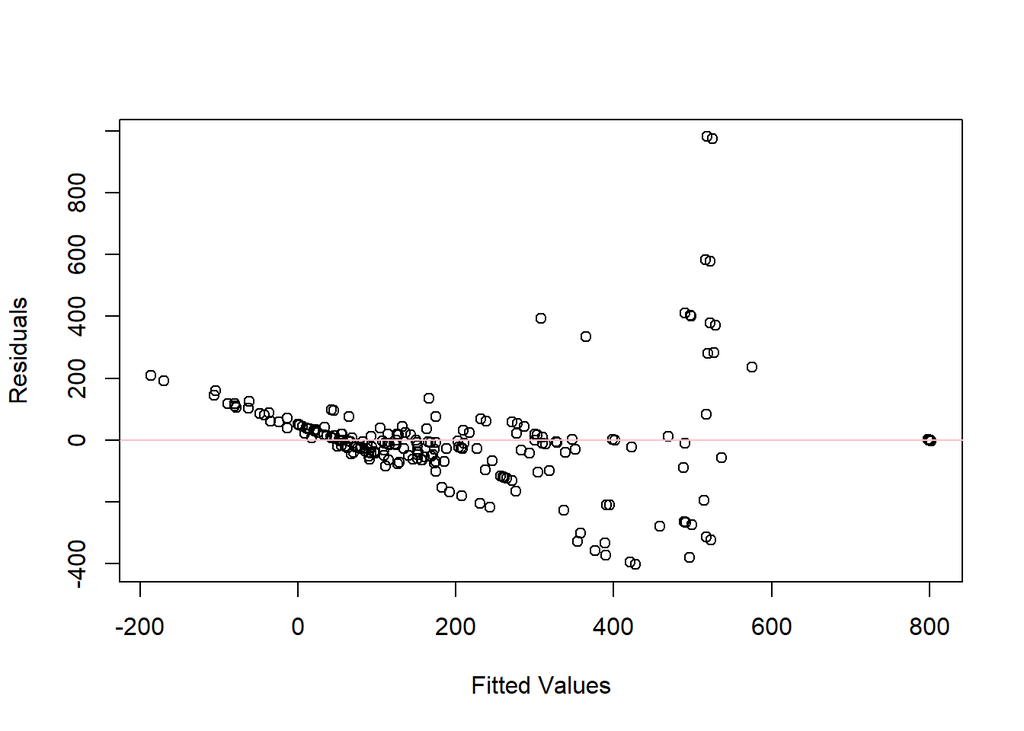

I observed an increasing pattern in the upper right corner of the chart. Residuals spread more as fitted values increase. This points to problems with the model’s **heteroscedasticity** and **linearity** assumption, meaning that the variance of the errors varies depending on the level of the dependent variable.  
The last assumption to check is normality assumption.

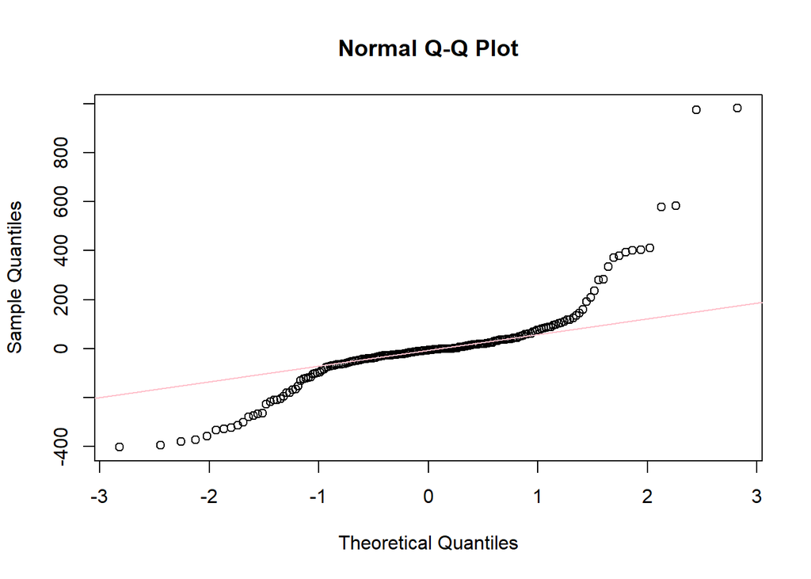

The p-value I see from the F-statistic is **less than alpha**, which means that at least one model coefficient has a **strong effect** on the dependent variable. So I can **reject H0** (The Null Hypothesis).  
**h)**  
I have a data set with various information of many different CPUs. I trained and optimized a machine learning model using the Multiple Linear Regression algorithm. I also applied some statistical tests throughout this process. As a result of tests, I proved that at least one of the columns in the dataset has a **large impact** on the prediction of the CycleTime of a new CPU.